# PSYCH 260/BBH 203

2022-03-03 11:44:31

## Prelude 8:01

[video not shown]

[(carlsagandotcom, 2009)](https://www.youtube.com/watch?v=gZpsVSVRsZk)

## Today’s topic

- How the human brain develops

## Timeline of milestones

[figure not shown]

[(Silbereis, Pochareddy, Zhu, Li, & Sestan, 2016)](http://dx.doi.org/10.1016/j.neuron.2015.12.008)

- Brain ~ 2.5% of body mass
  - consumes 18% of \(O_2\) at rest, [(Kety & Schmidt, 1948)](http://dx.doi.org/10.1172/JCI101994)
  - about 20 W
- CNS among earliest-developing, last to finish organ systems
  - Prolonged developmental period (==childhood) makes CNS especially vulnerable

## Neurons

- ~ 86 billion neurons in adult CNS
  - similar # of glia
- In cortex, about 16 (14-32) billion
  - 80/20% Glu/GABA
- Development generates millions neurons/hr

## Synapses

- 7-80K synapses/cortical neuron
- ~ \(10^{15}\) (quadrillion) synapses in CNS
- 164 trillion synapses in cerebral cortex, [(DeFelipe, Alonso-Nanclares, & Arellano, 2002)](http://dx.doi.org/10.1023/a:1024130211265)

## Axons

- 145-175 km (90-109 mi) of myelinated axons, [(Marner, Nyengaard, Tang, & Pakkenberg, 2003)](http://dx.doi.org/10.1002/cne.10714)

## Prenatal period

- 38 weeks from conception/fertilization on average
- Embryonic period (weeks 1-8), fetal period (weeks 9+)
- Divided into 3 12-13 week trimesters

## Insemination

- Can occur 3-4 days before or up to 1-2 days after…ovulation
- Some animals signal ovulation; humans do not

## Fertilization

- Within ~ 24 hrs of ovulation

## Implantation

- Fertilized ovum implants in wall of uterus
- ~ 6 days after fertilization

## Early embryogenesis

[video not shown]

## Formation of *neural tube* (neurulation)

[figure not shown]

- Embryonic layers: ectoderm, mesoderm, endoderm
  - Neural tube forms ~ 23 pcd (postconceptual days)
- Neural tube closes in middle, moves toward rostral & caudal ends, closing by 29 - 30 pcd.
- Failures of neural tube closure
  - Anencephaly (rostral neuraxis)
  - Spina bifida (caudal neuraxis)

## Spina bifida

[figure not shown]

https://www.mayoclinic.org/diseases-conditions/spina-bifida/symptoms-causes/syc-20377860

## Neural tube becomes…

- Ventricles & cerebral aqueduct
- Central canal of spinal cord

[figure not shown]

## Differential growth of vesicles

- Rostro-caudal patterning via differential growth into vesicles
  - Forebrain (prosencephalon)
  - Midbrain (mesencephalon)
  - Hindbrain (rhombencephalon)

## Neurogenesis and gliogenesis

- Neuroepithelium cell layer adjacent to neural tube
  - creating ventricular zone (VZ) and subventricular zone (SVZ)
- Pluripotent stem and progenitor cells divide, produce new neurons & glia

[figure not shown]

[(Götz & Huttner, 2005)](https://doi.org/10.1038/nrm1739)

## Old (adult) brains new neurons?

- Some animals, yes == songbirds, birds that store food caches
- Humans, on much more limited scale
  - hippocampus
  - striatum
  - olfactory bulb (minimally)
  - not much, if any, in cerebral cortex
- Most neurogenesis occurs near ventricles

[figure not shown]

[Ernst & Frisen 2015](https://doi.org/10.1371/journal.pbio.1002045)

## Neural progenitor/stem cells

- Undergo *symmetric* & *asymmetric* cell division
- Generate glia, neurons, and basal progenitor cells

## Radial glia and cell migration

[figure not shown]

[figure not shown]

[video not shown]

## Axon growth cone

[video not shown]

## Growth cones guided by

- Chemoattractants
  - e.g., Nerve Growth Factor (NGF)
- Chemorepellents
- Receptors in growth cone detect chemical gradients

[interactive chart not shown]

## Glia migrate, too

[figure not shown]

[(Baumann & Pham-Dinh, 2001)](http://dx.doi.org/10.1152/physrev.2001.81.2.871)

## Differentiation

- Neuron vs. glial cell
- Cell type
  - myelin-producing vs. astrocyte vs. microglia
  - pyramidal cell vs. stellate vs. Purkinje vs. …
- NTs released
- Where to connect

## Infancy & Early Childhood

## Synaptogenesis

- Begins prenatally (~ 18 pcw)
- Peak density ~ 15 mos postnatal
- Spine density in prefrontal cortex ~ 7 yrs postnatal
- 700K synapses/s on average

[figure not shown]

## Proliferation, pruning

- Early proliferation (make many synapses)
- Later pruning
- Rates, peaks differ by area

## Apoptosis (programmed cell death)

[interactive chart not shown]

- 20-80%, varies by area
- Spinal cord >> cortex
- Quantity of nerve growth factors (NGF) influences

## Synaptic rearrangement

[figure not shown]

- Progressive phase: growth rate >> loss rate
- Regressive phase: growth rate << loss rate

## Myelination

[figure not shown]

[(Baumann & Pham-Dinh, 2001)](http://dx.doi.org/10.1152/physrev.2001.81.2.871)

- Neonatal brain largely unmyelinated
- Gradual myelination, peaks in mid-20s
- Non-uniform pattern
  - Spinal cord before brain
  - Sensory before motor

## Gyral development (12-19 pcw)

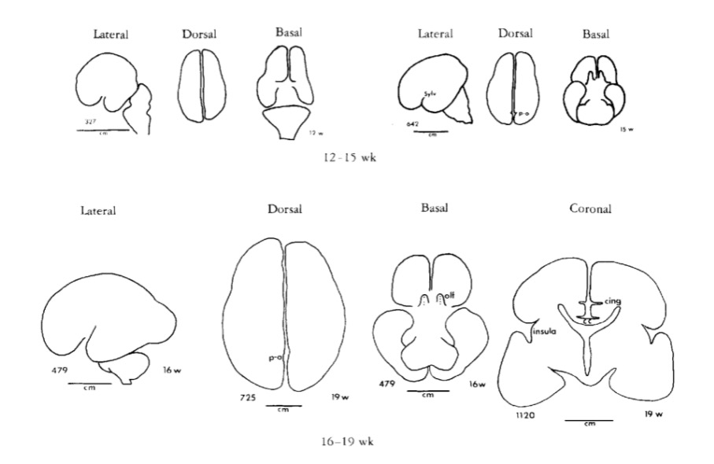

[(Chi, Dooling, & Gilles, 1977)](http://doi.org/10.1002/ana.410010109)

## 20-27 pcw

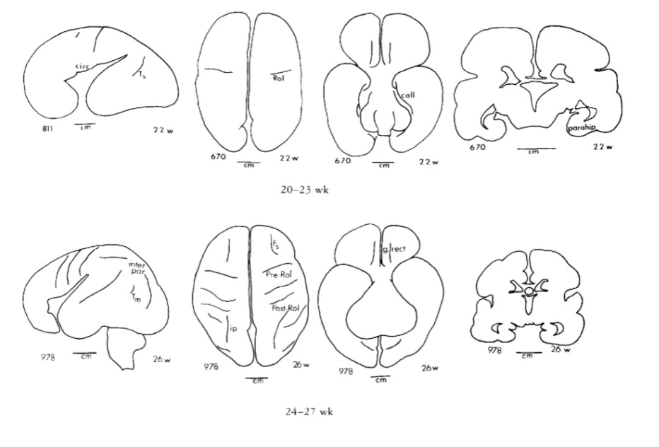

[(Chi et al., 1977)](http://doi.org/10.1002/ana.410010109)

## 28-35 pcw

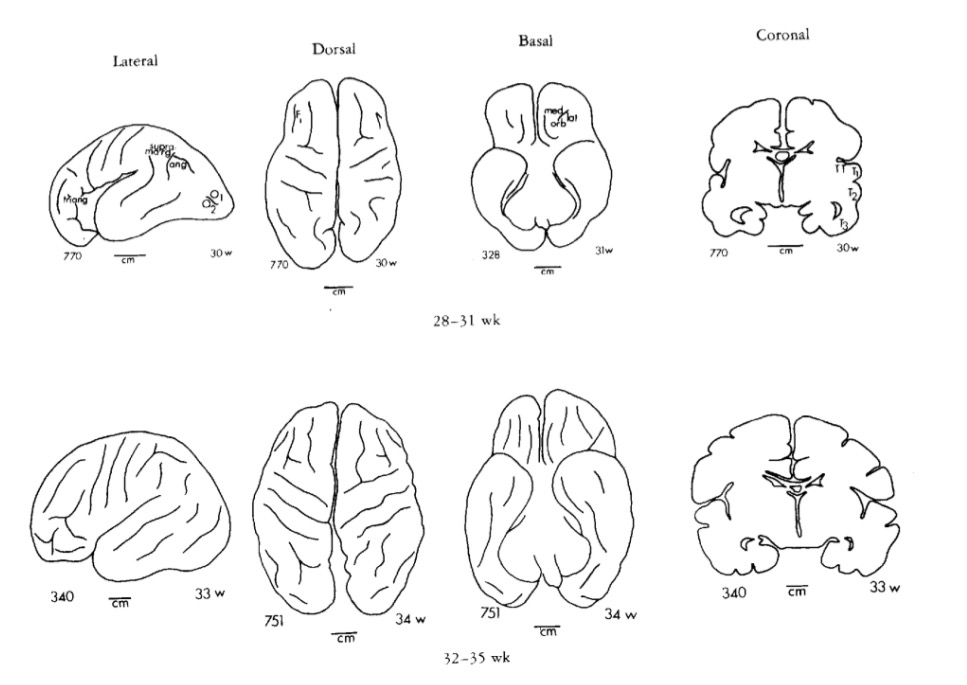

[(Chi et al., 1977)](http://doi.org/10.1002/ana.410010109)

## 36-44 pcw

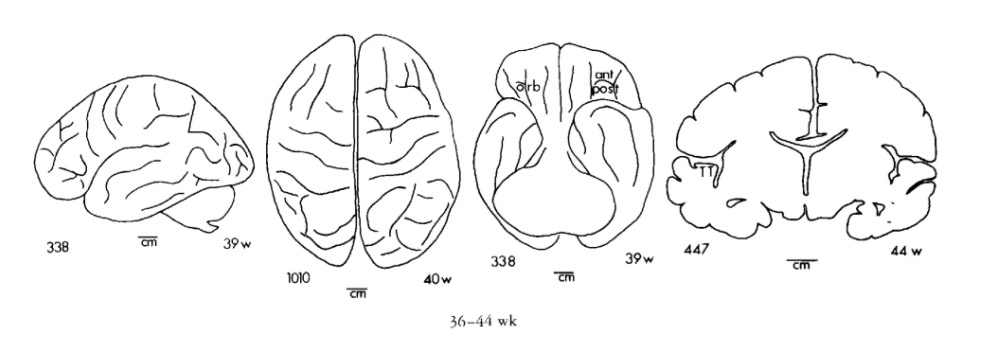

[(Chi et al., 1977)](http://doi.org/10.1002/ana.410010109)

## Structural/morphometric development

[figure not shown]

[(Knickmeyer et al., 2008)](http://doi.org/10.1523/JNEUROSCI.3479-08.2008)

## Myelination across human development

[figure not shown]

[(Hagmann et al., 2010)](http://doi.org/10.1073/pnas.1009073107)

## Changes in brain glucose use

[figure not shown]

[(Kuzawa et al., 2014)](http://doi.org/10.1073/pnas.1323099111)

## Gene expression across development

[figure not shown]

[(Kang et al., 2011)](http://doi.org/10.1038/nature10523)

## Summary of developmental milestones

## Prenatal

- Neuro- and gliogenesis
- Migration
- Synaptogenesis begins
- Differentiation
- Apoptosis
- Myelination begins

## Postnatal

- Synaptogenesis
- Cortical expansion, activity-dependent change
- Then cubic, quadratic, or linear declines in cortical thickness
- Myelination
- Prolonged period of postnatal/pre-reproductive development [(Konner, 2011)](http://www.hup.harvard.edu/catalog.php?isbn=9780674062016)

## Timeline of milestones

[figure not shown]

[(Silbereis et al., 2016)](http://dx.doi.org/10.1016/j.neuron.2015.12.008)

## References

Baumann, N., & Pham-Dinh, D. (2001). Biology of oligodendrocyte and myelin in the mammalian central nervous system. *Physiological Reviews*, *81*(2), 871–927. https://doi.org/10.1152/physrev.2001.81.2.871

carlsagandotcom. (2009, February). Carl sagan - COSMOS - evolution. Youtube. Retrieved from https://www.youtube.com/watch?v=gZpsVSVRsZk

Chi, J. G., Dooling, E. C., & Gilles, F. H. (1977). Gyral development of the human brain. *Ann. Neurol.*, *1*(1), 86–93. https://doi.org/10.1002/ana.410010109

DeFelipe, J., Alonso-Nanclares, L., & Arellano, J. I. (2002). Microstructure of the neocortex: Comparative aspects. *Journal of Neurocytology*, *31*(3-5), 299–316. https://doi.org/10.1023/a:1024130211265

Götz, M., & Huttner, W. B. (2005). The cell biology of neurogenesis. *Nat. Rev. Mol. Cell Biol.*, *6*(10), 777–788. https://doi.org/10.1038/nrm1739

Hagmann, P., Sporns, O., Madan, N., Cammoun, L., Pienaar, R., Wedeen, V. J., … Grant, P. E. (2010). White matter maturation reshapes structural connectivity in the late developing human brain. *Proceedings of the National Academy of Sciences*, *107*(44), 19067–19072. https://doi.org/10.1073/pnas.1009073107

Kang, H. J., Kawasawa, Y. I., Cheng, F., Zhu, Y., Xu, X., Li, M., … Šestan, N. (2011). Spatio-temporal transcriptome of the human brain. *Nature*, *478*(7370), 483–489. https://doi.org/10.1038/nature10523

Kety, S. S., & Schmidt, C. F. (1948). The Nitrous OXIDE METHOD FOR THE QUANTITATIVE DETERMINATION OF CEREBRAL BLOOD FLOW IN MAN: THEORY, PROCEDURE AND NORMAL VALUES. *The Journal of Clinical Investigation*, *27*(4), 476–483. https://doi.org/10.1172/JCI101994

Knickmeyer, R. C., Gouttard, S., Kang, C., Evans, D., Wilber, K., Smith, J. K., … Gilmore, J. H. (2008). A structural MRI study of human brain development from birth to 2 years. *J. Neurosci.*, *28*(47), 12176–12182. https://doi.org/10.1523/JNEUROSCI.3479-08.2008

Konner, M. (2011). *The Evolution of Childhood*. Belknap Press of Harvard University Press. Retrieved from http://www.hup.harvard.edu/catalog.php?isbn=9780674062016

Kuzawa, C. W., Chugani, H. T., Grossman, L. I., Lipovich, L., Muzik, O., Hof, P. R., … Lange, N. (2014). Metabolic costs and evolutionary implications of human brain development. *Proc. Natl. Acad. Sci. U. S. A.*, *111*(36), 13010–13015. https://doi.org/10.1073/pnas.1323099111

Marner, L., Nyengaard, J. R., Tang, Y., & Pakkenberg, B. (2003). Marked loss of myelinated nerve fibers in the human brain with age. *The Journal of Comparative Neurology*, *462*(2), 144–152. https://doi.org/10.1002/cne.10714

Silbereis, J. C., Pochareddy, S., Zhu, Y., Li, M., & Sestan, N. (2016). The cellular and molecular landscapes of the developing human central nervous system. *Neuron*, *89*(2), 248–268. https://doi.org/10.1016/j.neuron.2015.12.008